# Clustering

```r
# should only have the text responses to convert to factors
# stopifnot(all(lapply(wide, class) == "character"))
# q3.1_unique <- length(wide$Q3.1 %>% unique())
# numeric_data <- purrr::map_df(wide, ~as.numeric(as.factor(.)))
# stopifnot(length(unique(numeric_data$Q3.1)) == q3.1_unique)
#
# rownames(numeric_data) <- rownames(wide)
```

# The data

```r
tail(numeric_data)
```

|  | Q3.1 | Q3.3 | Q3.4 | Q3.5 | Q3.6 | Q3.7 | Q4.1 | Q4.2 | Q4.3 | Q4.4 | Q5.1 | Q5.2 | Q6.1 | Q6.2 | Q6.3 | Q6.4 |
| --- | --- | --- | --- | --- | --- | --- | --- | --- | --- | --- | --- | --- | --- | --- | --- | --- |
| 61 | 4 | 6 | 4 | 3 | 4 | 1 | 1 | 3 | 3 | 1 | 2 | 5 | 2 | 2 | 2 | 1 |
| 62 | 3 | 3 | 2 | 3 | 1 | 2 | 4 | 3 | 3 | 1 | 3 | 2 | 1 | 1 | 2 | 1 |
| 63 | 4 | 7 | 6 | 4 | 1 | 2 | 4 | 4 | 4 | 4 | 2 | 6 | 3 | 3 | 4 | 2 |
| 64 | 5 | 7 | 5 | 4 | 2 | 2 | 4 | 3 | 4 | 4 | 4 | 5 | 4 | 3 | 3 | 4 |
| 65 | 3 | 3 | 2 | 2 | 2 | 1 | 3 | 3 | 1 | 3 | 2 | 2 | 1 | 1 | 1 | 1 |
| 67 | 3 | 4 | 2 | 3 | 2 | 2 | 4 | 4 | 4 | 3 | 2 | 2 | 3 | 3 | 3 | 1 |

The data are the numeric (factor) survey responses. They are not `scale`d, but the units are arbitrary. Using `scale` would scale/standardize the results. But these are factor responses, not an actual measurement. **This needs to be consulted.**

Scaling the data would look like this:

```r
numeric_data_scaled <- scale(numeric_data)
```

```r
numeric_data_scaled[1:5, 1:6]
```

```
##        Q3.1       Q3.3        Q3.4        Q3.5       Q3.6       Q3.7
## 1 0.6227137 -0.0417848 -0.08090421 -0.83344772 -0.8320621 -0.6410685
## 2 0.6227137  0.4512759  0.51576431  0.02924378  2.2361670  0.1636771
## 3 1.4577161  1.9304579  2.30576985  1.75462678  1.4691097 -0.6410685
## 4 0.6227137 -0.0417848  1.70910134  0.02924378 -0.8320621 -0.6410685
## 5 0.6227137 -0.5348455 -0.67757272 -0.83344772 -0.8320621 -0.6410685
```

# PCA

```r
pca_persona_scaled <- prcomp(numeric_data_scaled)
summary(pca_persona_scaled)
```

```
## Importance of components:
##                           PC1    PC2     PC3    PC4     PC5     PC6     PC7     PC8     PC9   PC10
## Standard deviation     2.6800 1.4596 1.15573 0.9741 0.91681 0.88377 0.78099 0.75829 0.63741 0.5892
## Proportion of Variance 0.4489 0.1332 0.08348 0.0593 0.05253 0.04882 0.03812 0.03594 0.02539 0.0217
## Cumulative Proportion  0.4489 0.5820 0.66553 0.7248 0.77737 0.82618 0.86430 0.90024 0.92563 0.9473
##                           PC11    PC12    PC13    PC14   PC15    PC16
## Standard deviation     0.54004 0.41541 0.38242 0.32698 0.2712 0.22761
## Proportion of Variance 0.01823 0.01079 0.00914 0.00668 0.0046 0.00324
## Cumulative Proportion  0.96556 0.97634 0.98548 0.99217 0.9968 1.00000
```

```r
saveRDS(pca_persona_scaled, file = here(glue::glue("./output/persona/{params$survey_data}/pca_results.RDS")))
```

```r
pca_table_mat <- t(summary(pca_persona_scaled)$importance)
components <- rownames(pca_table_mat)

pca_results_df <- pca_table_mat %>%
  tibble::as_tibble() %>%
  dplyr::mutate(component = components,
                compont_num = stringr::str_replace(component, "PC", "") %>%
                  as.numeric())
pca_results_df
```

| Standard deviation | Proportion of Variance | Cumulative Proportion | component | compont_num |
| --- | --- | --- | --- | --- |
| 2.6799668 | 0.44889 | 0.44889 | PC1 | 1 |
| 1.4596274 | 0.13316 | 0.58205 | PC2 | 2 |
| 1.1557326 | 0.08348 | 0.66553 | PC3 | 3 |
| 0.9741009 | 0.05930 | 0.72483 | PC4 | 4 |
| 0.9168130 | 0.05253 | 0.77737 | PC5 | 5 |
| 0.8837673 | 0.04882 | 0.82618 | PC6 | 6 |
| 0.7809889 | 0.03812 | 0.86430 | PC7 | 7 |
| 0.7582888 | 0.03594 | 0.90024 | PC8 | 8 |
| 0.6374053 | 0.02539 | 0.92563 | PC9 | 9 |
| 0.5891738 | 0.02170 | 0.94733 | PC10 | 10 |
| 0.5400413 | 0.01823 | 0.96556 | PC11 | 11 |
| 0.4154082 | 0.01079 | 0.97634 | PC12 | 12 |
| 0.3824227 | 0.00914 | 0.98548 | PC13 | 13 |
| 0.3269848 | 0.00668 | 0.99217 | PC14 | 14 |
| 0.2711992 | 0.00460 | 0.99676 | PC15 | 15 |
| 0.2276055 | 0.00324 | 1.00000 | PC16 | 16 |

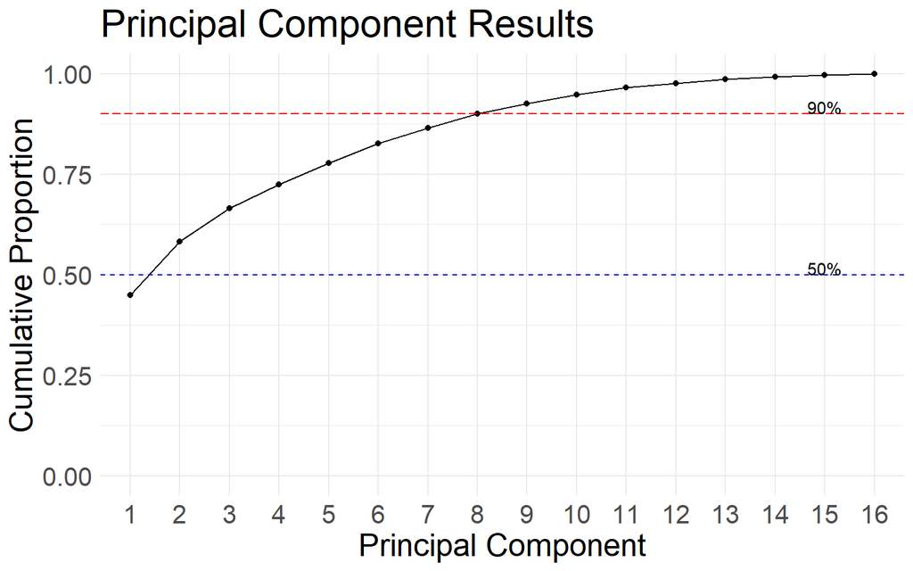

```r
ggplot(pca_results_df,
       aes(x = as.factor(compont_num),
           y = `Cumulative Proportion`,
           group = 1)) +
  geom_point() +
  geom_line() +
  ylim(0, 1) +
  geom_hline(yintercept = 0.5, linetype = 'dashed', col = 'blue') +
  geom_hline(yintercept = 0.9, linetype = 'longdash', col = 'red') +
  annotate("text", x = "15", y = 0.5, label = "50%", vjust = 0) +
  annotate("text", x = "15", y = 0.9, label = "90%", vjust = 0) +
  labs(title = "Principal Component Results",
       x = "Principal Component") +
  theme_minimal() +
  theme(text = element_text(size=20))
```

```r
ggsave(here(glue::glue("./output/persona/{params$survey_data}/pca_cum_prop.png")))
```

Half of the components account for >90% of the variance. Will need to confirm these results with factor analysis, but this makes sense since I tried to ask the same questions in 2 ways.

# Hierarchical Clustering

https://uc-r.github.io/hc_clustering

```r
dist <- dist(numeric_data_scaled, method = "euclidean")
```

## Finding the clustering method

### Complete

Computes pairwise similarities, and the “most” (i.e., maximum) similar ones are grouped together

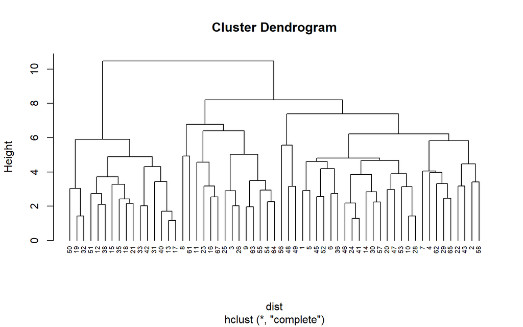

```r
# Hierarchical Clustering with hclust
hc_complete <- hclust(dist, method = "complete")
# Plot the result
plot(hc_complete, cex = 0.6, hang = -1)
```

### Ward’s

Minimizes the total **within cluster** variance.

From the docs:

> Two different algorithms are found in the literature for Ward clustering. The one used by option “ward.D” (equivalent to the only Ward option “ward” in R versions <= 3.0.3) does not implement Ward’s (1963) clustering criterion, whereas option “ward.D2” implements that criterion (Murtagh and Legendre 2014). With the latter, the dissimilarities are squared before cluster updating. Note that agnes(*, method=“ward”) corresponds to hclust(*, “ward.D2”).

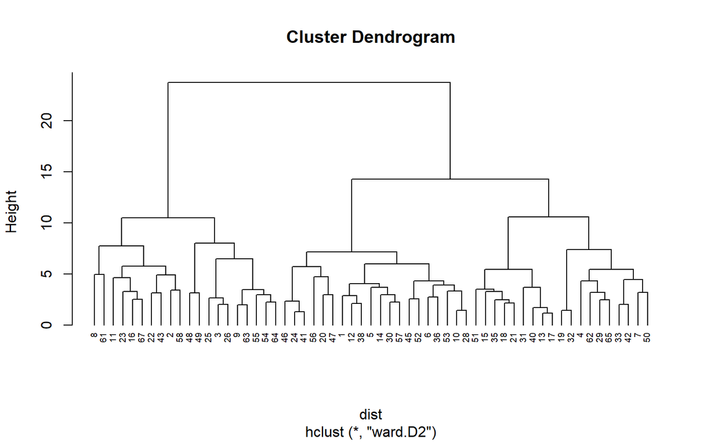

```r
hc_ward <- hclust(dist, method = "ward.D2")
# Plot the result
plot(hc_ward, cex = 0.6, hang = -1)
```

### Comparing dendograms

Calculate agglomerative coefficient (closer to 1 mean stronger clustering structure)

```r
m <- c("average", "single", "complete", "ward")
names(m) <- c( "average", "single", "complete", "ward")

purrr::map_dbl(m, ~ cluster::agnes(numeric_data_scaled, method = .)$ac)
```

```
##   average    single  complete      ward
## 0.6091632 0.4536597 0.7450615 0.8868398
```

Ward’s gives us the best clustering structure

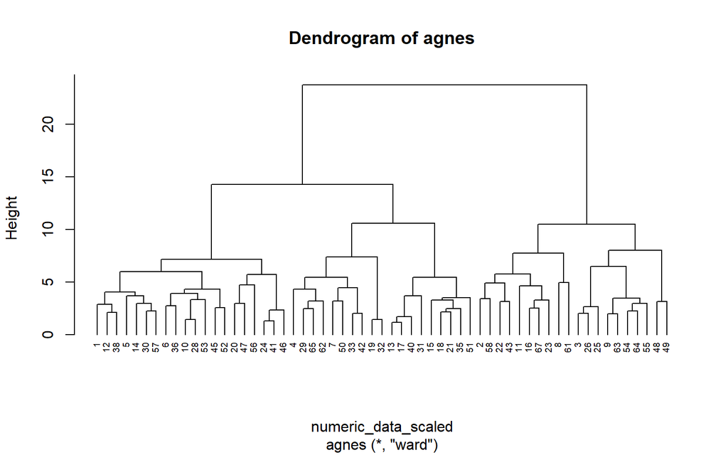

```r
hc_agnes_wards <- agnes(numeric_data_scaled, method = "ward")
cluster::pltree(hc_agnes_wards, cex = 0.6, hang = -1, main = "Dendrogram of agnes")
```

## Cutting the tree to create clusters

```r
hc_ward
```

```
##
## Call:
## hclust(d = dist, method = "ward.D2")
##
## Cluster method   : ward.D2
## Distance         : euclidean
## Number of objects: 59
```

```r
sub_grp2 <- cutree(hc_ward, k = 2)
sub_grp3 <- cutree(hc_ward, k = 3)
sub_grp4 <- cutree(hc_ward, k = 4)
sub_grp5 <- cutree(hc_ward, k = 5)
sub_grp6 <- cutree(hc_ward, k = 6)
```

```r
numeric_data <- numeric_data %>%
  dplyr::mutate(
    group2 = sub_grp2,
    group3 = sub_grp3,
    group4 = sub_grp4,
    group5 = sub_grp5,
    group6 = sub_grp6
  )
rownames(numeric_data) <- rownames(wide)
```

```r
plot_all_dendros <- function(hc_dat, k, ...) {
  png(here::here(glue::glue("./output/persona/{params$survey_data}/dendogram_{k}.png")),
      width = 13, height = 8, units = "in", res = 72)
  plot(hc_ward, cex = 0.6)
  rect.hclust(hc_ward, k = k, border = 2:3)
  dev.off()

  g <- gg_plot_dendro(hc_ward, ...)
  print(g)

  ggsave(here::here(glue::glue("./output/persona/{params$survey_data}/dendogram_{k}_gg.png")),
         plot = g,
         width = 13, height = 8, units = "in", dpi = 72)
}
```

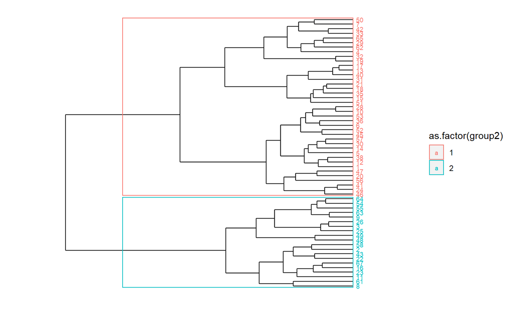

```r
plot_all_dendros(hc_ward, k = 2, group2)
```

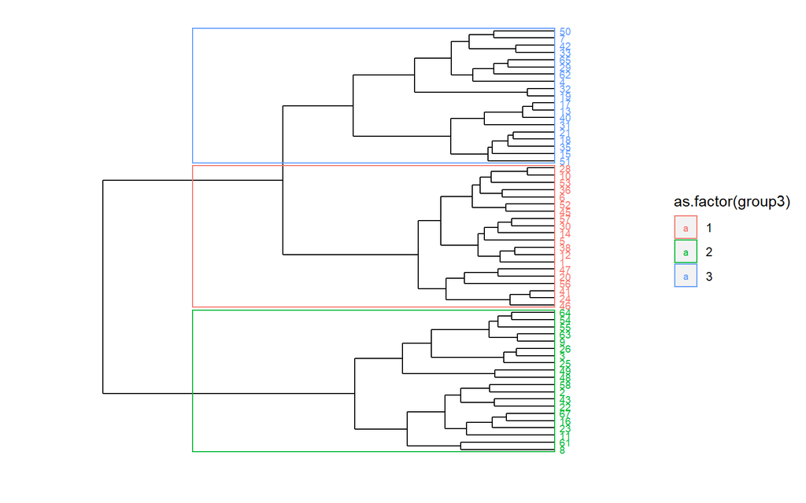

```r
plot_all_dendros(hc_ward, k = 3, group3)
```

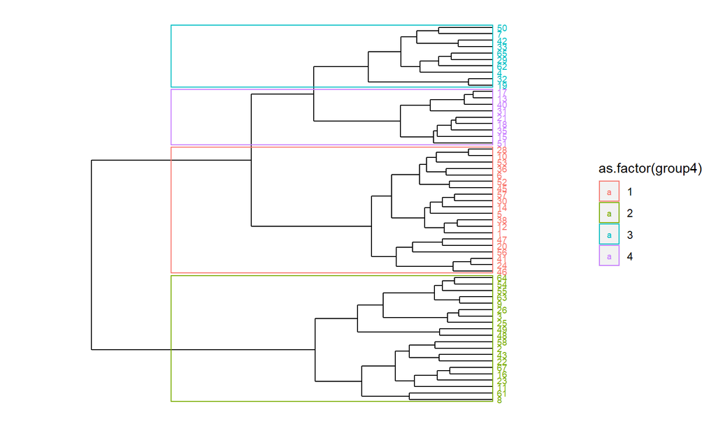

```r
plot_all_dendros(hc_ward, k = 4, group4)
```

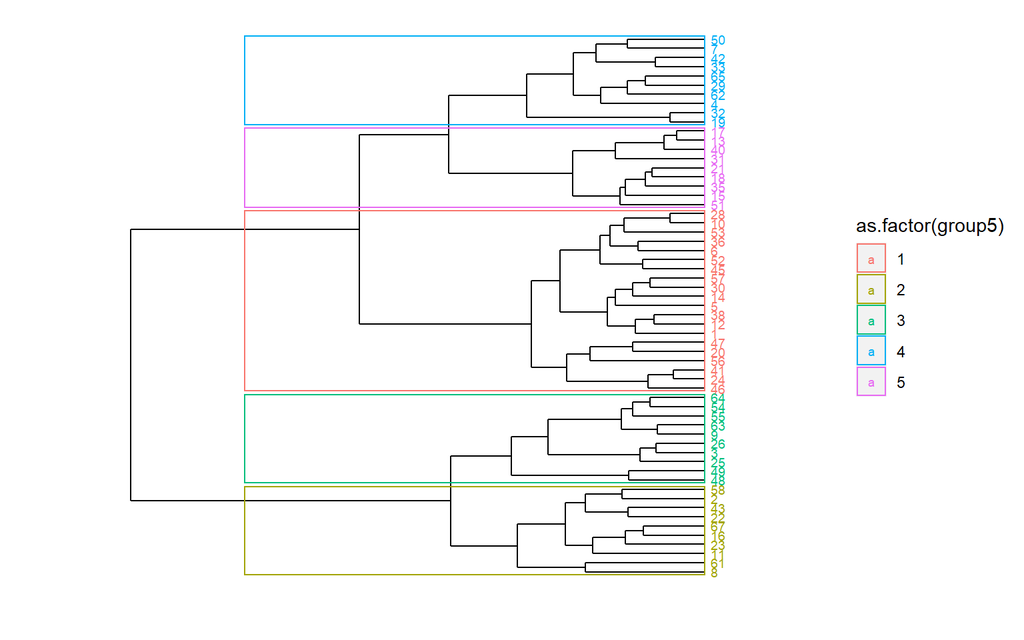

```r
plot_all_dendros(hc_ward, k = 5, group5)
```

### Finding optimal clusters

```r
# https://www.r-bloggers.com/2017/12/how-to-perform-hierarchical-clustering-using-r/
# https://www.r-bloggers.com/2019/01/10-tips-for-choosing-the-optimal-number-of-clusters/
```

#### Elbow method

https://uc-r.github.io/kmeans_clustering#elbow

```r
png(here(glue::glue("./output/persona/{params$survey_data}/elbow_plot.png")))
factoextra::fviz_nbclust(numeric_data_scaled, FUN = factoextra::hcut, method = "wss")
dev.off()
```

#### Gap statistic

```r
png(here(glue::glue("./output/persona/{params$survey_data}/gap_statistic.png")))
gap_stat <- clusGap(numeric_data_scaled, FUN = kmeans, nstart = 30, K.max = 24, B = 50)
```

```
## Clustering k = 1,2,..., K.max (= 24): .. done
## Bootstrapping, b = 1,2,..., B (= 50)  [one "." per sample]:
## .................................................. 50
```

```r
fviz_gap_stat(gap_stat) + theme_minimal() + ggtitle("fviz_gap_stat: Gap Statistic")
dev.off()
```

Will need to look at the results to see if they create meaningful personas

# Write out group data

```r
gps <- 2:5

fs::dir_create(here(glue::glue("./data/final/persona/{params$survey_data}/")))
persona_df_pths <- here(glue::glue("./data/final/persona/{params$survey_data}/persona_group_{gps}.tsv"))
cols <- glue::glue("group{gps}")

persona_groups <- purrr::map(
  cols,
  function(x) {
    group_data <- numeric_data %>%
      tibble::rownames_to_column(var = "id_person") %>%
      dplyr::select(id_person, {{ x }})

    stopifnot(nrow(numeric_data_scaled) == nrow(group_data))
    stopifnot(all(unique(group_data$id_person) %in% unique(persona$id_person)))

    dat <- persona %>%
      dplyr::mutate(id_person = as.character(id_person)) %>%
      dplyr::left_join(group_data, by = c("id_person" = "id_person"))

    return(dat)
  }
)

purrr::walk2(
  persona_groups,
  persona_df_pths,
  function(dat, pth){readr::write_tsv(dat, pth)}
)
```

# K-Means

https://uc-r.github.io/kmeans_clustering

```r
numeric_data_scaled
```

[output not shown]

[output cut: 115 more lines]

```r
library(tidyverse)  # data manipulation
library(cluster)    # clustering algorithms
library(factoextra) # clustering algorithms & visualization
```

```r
dist <- factoextra::get_dist(numeric_data_scaled, method = "euclidean")
```

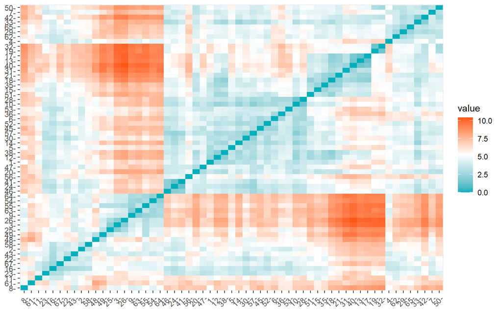

```r
fviz_dist(dist, gradient = list(low = "#00AFBB", mid = "white", high = "#FC4E07"))
```

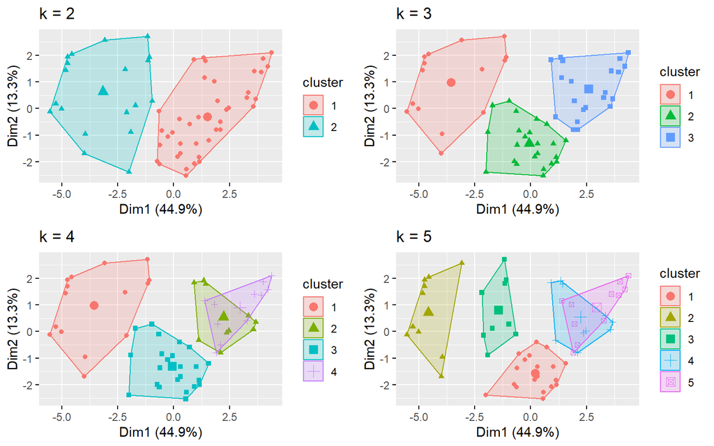

```r
k2 <- kmeans(numeric_data_scaled, centers = 2, nstart = 25)
k3 <- kmeans(numeric_data_scaled, centers = 3, nstart = 25)
k4 <- kmeans(numeric_data_scaled, centers = 4, nstart = 25)
k5 <- kmeans(numeric_data_scaled, centers = 5, nstart = 25)

# plots to compare
pk2 <- fviz_cluster(k2, geom = "point", data = numeric_data_scaled) + ggtitle("k = 2")
pk3 <- fviz_cluster(k3, geom = "point", data = numeric_data_scaled) + ggtitle("k = 3")
pk4 <- fviz_cluster(k4, geom = "point", data = numeric_data_scaled) + ggtitle("k = 4")
pk5 <- fviz_cluster(k5, geom = "point", data = numeric_data_scaled) + ggtitle("k = 5")

library(gridExtra)
grid.arrange(pk2, pk3, pk4, pk5, nrow = 2)
```